# R data in and out dummies

Kenny

Thursday, January 22, 2015

### Entering data in the R text editor

> note: you cannot modify column names here

```
elements <- data.frame()

elements <- edit(elements) # then save the data

print(elements) # both fine to check the data

elements
```

### Using the Clipboard to copy and paste

```
# first, select and copy from spreadsheet, then
x <- readClipboard()
x

# if dealing with tabular data, use read.table()
x <- read.table(file = "clipboard", sep = "\t", header=TRUE)
x
```

### Reading data in CSV files

### Using read.csv() to import data

```
elements <- read.csv(file.path("f:", "elements.csv"))
# the default option is to convert character strings into factors

str(elements)

elements <- read.csv(file.path("f:", "elements.csv"), stringsAsFactors=FALSE)

str(elements)
```

> R converts spaces in the column names to periods (for example, in the column State.At.STP).

> **Using read.table() arguments**  
> The read.table() function has a number of arguments that give you fine control over the specification of the text file you want to import. Here are some of these arguments:

> header: header = TRUE

> quote: return with string with “”, if ‘string’ in txt file, we need to use quote = “’”

> nrows: specify which rows to read

> skip: allow to ignore a number of rows from top

### Reading data from Excel

```
install.packages("XLConnect")

library("XLConnect")

excel.file <- file.path("~/Elements.xlsx")

elements <- readWorksheetFromFile(excel.file, sheet=1)

elements <- readWorksheetFromFile(excel.file, sheet="Sheet1")
```

> **Difficulty in installing this package**:

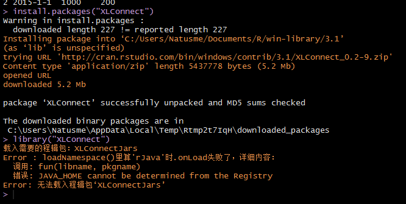

### Working with other data types

```
library(foreign)

read.spss(file="location/of/myfile")
```

> **Difficult foreign software import function**:

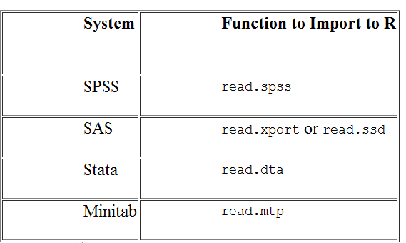

### Getting Your Data out of R

```
# this only works for a row of data or vector
writeClipboard(names(iris))

# cope and paste outside of R about tabular data
write.table(head(iris), file="clipboard", sep="\t", row.names=FALSE)
```

### Working with Files and Folders

> getting and setting working directory

[output not shown]

### Manipulating files

```
list.files(file.path("F:", "git", "roxygen2"))

[1] “roxygen2”            “roxygen2.Rcheck”
[3] “roxygen2_2.0.tar.gz” “roxygen2_2.1.tar.gz”
```

> **functions on manipulate files**:

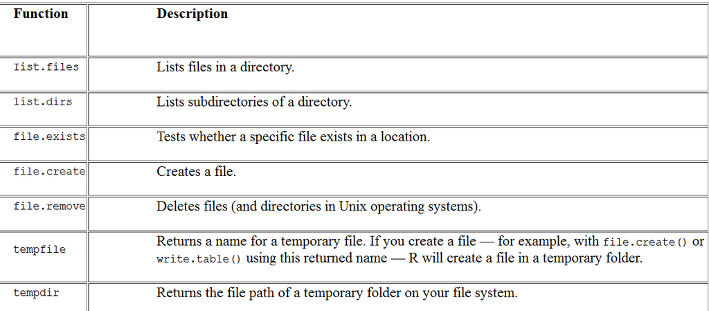

> In the next example, you first **create a temporary file**, then **save a copy of the iris data frame to this file**. To test that the file is on disk, you then **read the newly created file to a new variable and inspect this variable**. Finally, you **delete the temporary file from disk**.

```
my.file <- tempfile() # link my.file to the name of a file in a temporary folder on your system

my.file # return the name of the temporary file in temporary folder

[1] “C:\\Users\\Andrie\\AppData\\Local\\Temp\\ RtmpGYeLTj\\file14d4366b6095”

write.csv(iris, file=my.file) # read the object into the temporary file as CSV file

list.files(tempdir())
# tempdir() return the path of temporary folder
# list.files() show the names of temporary file in the temporary directory

[1] “file14d4366b6095”
```

```
file.iris <- read.csv(my.file) # read data of CSV file into object file.iris

str(file.iris) # row.nameS = TRUE by default, X as row names is included below

‘data.frame’:                              150 obs. of  6 variables:
$ X           : int  1 2 3 4 5 6 7 8 9 10 ...
$ Sepal.Length: num  5.1 4.9 4.7 4.6 5 5.4 4.6 5 4.4 4.9 ...
$ Sepal.Width : num  3.5 3 3.2 3.1 3.6 3.9 3.4 3.4 2.9 3.1 ...
$ Petal.Length: num  1.4 1.4 1.3 1.5 1.4 1.7 1.4 1.5 1.4 1.5 ...
$ Petal.Width : num  0.2 0.2 0.2 0.2 0.2 0.4 0.3 0.2 0.2 0.1 ...
$ Species     : Factor w/ 3 levels “setosa”,”versicolor”,..: 1 1 1 1 1 1 1 1 1 1 ...

file.remove(my.file) # remove the temporary file

list.files(tempdir()) # check the temporary file from temporary directory
character(0)
```